# Preamble

SPDX-License-Identifier: AGPL-3.0-or-later OR GPL-2.0-or-later OR CERN-OHL-S-2.0+ OR Apache-2.0

If you are reading a html or other static output version of this python notebook you can find [the source python notebook](https://gitlab.com/Chips4Makers/c4m-pdk-ihpsg13g2/-/blob/main/sim/SimInputPerformance.ipynb) on the [c4m-pdk-ihpsg13g2 repository](https://gitlab.com/Chips4Makers/c4m-pdk-ihpsg13g2)

# Setup

```python
import sys
import numpy as np
from matplotlib import pyplot as plt

from c4m.pdk import ihpsg13g2

from corners import corner_spec
```

# Simulation

We set up a simulation on the IOPadIn cell with varying frequency and rise and fall time, to verify if 100MHz input frequency can be reached and what the duty ratio is on the `p2c` output to the core.

```
10.0
50.0
```

```
100.0
200.0
```

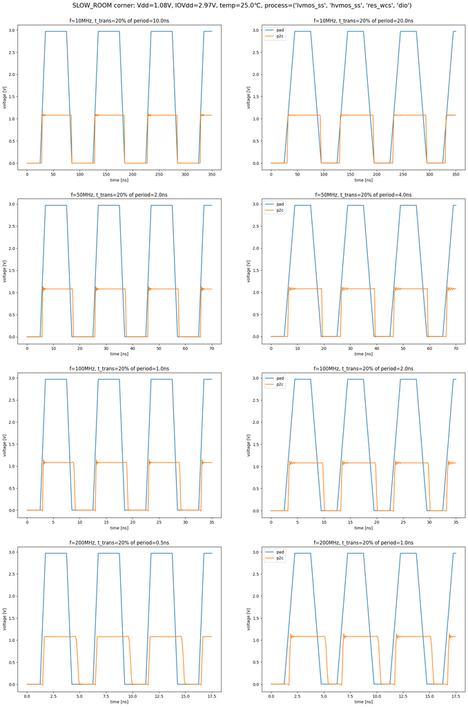

```python
# TODO: switch to SLOW if ngspice does not crash for it anymore
# corner = "SLOW"
corner = "SLOW_ROOM"
v_vdd, v_iovdd, temp, tc = corner_spec[corner]

freqs = (10e6, 50e6, 100e6, 200e6)
n_freqs = len(freqs)

# Ensure all cells are generated
ihpsg13g2.ihpsg13g2_iofab.get_cell("Gallery").circuit
ckt = ihpsg13g2.ihpsg13g2_iofab.get_cell("IOPadIn").circuit

fig = plt.figure(figsize=(20,30))
for i, freq in enumerate(freqs):
    print(freq/1e6)
    period = 1/freq
    for i2, t_trans in enumerate((0.1*period, 0.2*period)):
        tb = ihpsg13g2.pyspicefab.new_pyspicecircuit(corner=tc, top=ckt)

        tb.V("vss", "vss", tb.gnd, 0.0)
        tb.V("vdd", "vdd", tb.gnd, v_vdd)
        tb.V("iovss", "iovss", tb.gnd, 0.0)
        tb.V("iovdd", "iovdd", tb.gnd, v_iovdd)

        tb.C("p2c", "p2c", "vss", 10e-15)
        tb.PulseVoltageSource(
            "pad", "pad", "iovss",
            delay_time=0.25*period, period=period, pulse_width=(0.5*period - t_trans),
            rise_time=t_trans, fall_time=t_trans, initial_value=0.0, pulsed_value=v_iovdd,
        )

        sim = tb.simulator(temperature=temp, abstol=1e-9)

        plt.subplot(n_freqs, 2, 2*i + i2 + 1)
        trans = None
        try:
            trans = sim.transient(step_time=t_trans/10, end_time=3.5*period)
        except:
            try:
                trans = sim.transient(step_time=t_trans/5, end_time=3.5*period)
            except Exception as e:
                sys.stderr.write(
                    "Error running simulation\n"
                    f"{e}\n"
                )
                pass
        if trans is not None:
            time = 1e9*np.array(trans.time)
            pad = np.array(trans.pad)
            p2c = np.array(trans.p2c)

            plt.plot(time, pad, label="pad")
            plt.plot(time, p2c, label="p2c")
            plt.title(f"f={round(freq/1e6)}MHz, t_trans=20% of period={t_trans*1e9}ns")
            plt.xlabel("time [ns]")
            plt.ylabel("voltage [V]")
    plt.legend()
fig.text(
    x=0.22, y=0.90, s=f"{corner} corner: Vdd={v_vdd:.2f}V, IOVdd={v_iovdd:.2f}V, temp={temp}℃, process={tc}",
    size=15,
)
```

Unfortunately ngspice simulation in the `SLOW` corner failed so the simulations have been done in the `SLOW_ROOM` corner. This is using slow transistor corner but at room temperature.

One can see that 200MHz operation is not a problem for this corner. As the threshold is not centered around half of the IO Vdd the duty ratio of the core `p2c` is much dependent on the rise/fall time of the signal on the pad of the IO cell.